# TSF-GRIP-Feb 21’

Kevin Benny

## Data Science and Business Analytics

### TASK 1 : Prediction using Supervised ML

In this task, we will be using *Simple Linear Regression* to predict the percentage of a ‘Student’ based on the number of ‘Study Hours’ from the given dataset. We use R programming to both build our model and visualize the results.

### Loading the necessay packages

```r
library(ggplot2)
library(caTools)
```

### Downloading and loading the dataset

```r
url <- "https://raw.githubusercontent.com/AdiPersonalWorks/Random/master/student_scores%20-%20student_scores.csv"
dataset <- read.csv(url)
```

### Viewing the dataset

```r
head(dataset)
```

|  | Hours | Scores |
| --- | --- | --- |
| 1 | 2.5 | 21 |
| 2 | 5.1 | 47 |
| 3 | 3.2 | 27 |
| 4 | 8.5 | 75 |
| 5 | 3.5 | 30 |
| 6 | 1.5 | 20 |

### Building a plot of the dataset

We make a simple scatter plot to verify the graphical relation between our variables and find if they have a linear relationship if any.

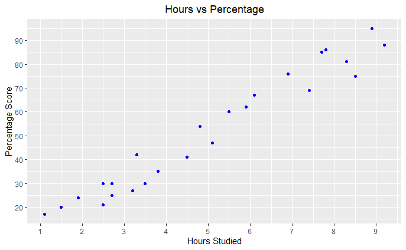

```r
plot <- ggplot()+
  geom_point(aes(x=dataset$Hours,y=dataset$Scores),col="blue")+
  scale_x_continuous(breaks = c(1:9),limits = lim_x)+
  scale_y_continuous(breaks = seq(0,100,by=10),limits = lim_y)+
  xlab("Hours Studied")+ylab("Percentage Score")+
  ggtitle("Hours vs Percentage")+
  theme(plot.title = element_text(hjust = 0.5))
plot
```

### Correlation

We find the correlation between the two variables to find if there is a positive or negative correlation between them if any

```r
correlation <- cor(dataset$Hours,dataset$Scores)
cat(paste("Correlation between Hours and Scores : ",correlation))
```

```
Correlation between Hours and Scores :  0.976190656022089
```

### Independent and Dependent Variables

In the Simple Linear Regression we need to identify the Independent(x) and Dependent(y) variables. Here we separate them into two variables respectively

```r
independent_var <- dataset$Hours
dependent_var <- dataset$Scores
print('Independent Variable : Hours')
```

```
[1] "Independent Variable : Hours"
```

```r
print('Dependent Variable : Scores')
```

```
[1] "Dependent Variable : Scores"
```

### Testing and Training Data

When dealing with machine learning models in general, it is always recommended to split our data into a training set and a testing set. This can easily be done using the sample.split() function of the CaTools package. A fraction of 20/80 is recommended for testing/training.

```r
set.seed(0)
split = sample.split(dataset$Scores, SplitRatio = 0.8)
training_set = subset(dataset, split == TRUE)
test_set = subset(dataset, split == FALSE)
```

### Training the Model

Now we have our training data ready and so the next step is to create the regression. This is done using the in-built function lm(). A summary table can also be generated but we will be looking at only the coefficients and their significance.

```r
regressor <- lm(formula = Scores ~ Hours,data = training_set)
cat("Training Complete\n\n")
```

```
Training Complete
```

```r
stats <- summary(regressor)
print("Coefficients")
```

```
[1] "Coefficients"
```

```r
print(stats$coefficients[,c(1,4)])
```

```
            Estimate     Pr(>|t|)
(Intercept) 2.312570 4.106490e-01
Hours       9.789487 1.590337e-13
```

### Predicting Values

Since, we have trained our data on the *regressor* it is time to make some predictions using the testing data that we had sourced earlier and compare the results.

```r
scores <- predict(regressor,newdata = test_set)
predicted_scores <- data.frame(test_set$Hours,test_set$Scores,scores)
names(predicted_scores) <- c("Hours","Scores","Predicted Scores")
rownames(predicted_scores) <- 1:nrow(predicted_scores)
print("Comparing the actual values and the preicted values of the test data")
```

```
[1] "Comparing the actual values and the preicted values of the test data"
```

```r
predicted_scores
```

|  | Hours | Scores | Predicted Scores |
| --- | --- | --- | --- |
| 1 | 3.5 | 30 | 36.57577 |
| 2 | 9.2 | 88 | 92.37585 |
| 3 | 5.5 | 60 | 56.15475 |
| 4 | 6.1 | 67 | 62.02844 |
| 5 | 4.8 | 54 | 49.30211 |

### Regression Visualization

Now we need to visualize our *regressor* and we plot a regression line along with our training data to visually see our regression accuracy.

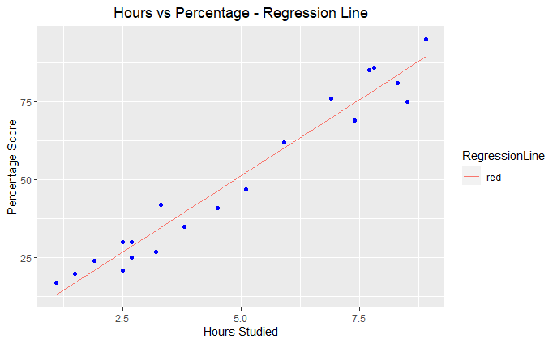

```r
plot <- ggplot()+
   geom_point(aes(x=training_set$Hours,y=training_set$Scores),col="blue")+geom_line(aes(x=training_set$Hours,y=predict(regressor,newdata = training_set),colour='red'))+     xlab("Hours Studied")+ylab("Percentage Score")+
   ggtitle("Hours vs Percentage - Regression Line")+
   theme(plot.title = element_text(hjust = 0.5))+
   labs(colour='RegressionLine')
plot
```

### Custom Prediction

Now we can give custom values to our *regressor* and make predictions.

```r
cat("Custom Prediction\n")
```

```
Custom Prediction
```

```r
sample <- data.frame(Hours=9.25)
print("Hours = 9.25")
```

```
[1] "Hours = 9.25"
```

```r
predicted_val <- predict(regressor,sample)
c <- paste("Predicted value = ",predicted_val)
c
```

```
[1] "Predicted value =  92.8653202768145"
```

### Model Evaluation

One of the most important things in Machine Learning is to check the various parameters of our model and evaluate the model. This can be useful when trying to improve our model. Some of evaluation parameters are the *R-Squared* , *Adjusted R-Squared* , *Mean Absolute Error* etc.

```r
cat("Evaluating the Regression Model\n")
```

```
Evaluating the Regression Model
```

```r
metrics <- data.frame(matrix(ncol = 2,nrow = 5))
names(metrics) <- c("Metric","Value")
mae <- MAE(test_set$Scores,predict(regressor,test_set))
mape <- MAPE(predict(regressor,test_set),test_set$Scores)
mnames <- c("R-Squared","Adj. R-Squared","MeanAbsoluteError","MeanAbsolutePercentageError","ResidualStandardError")
mvalues <- c(stats$r.squared,stats$adj.r.squared,mae,mape,stats$sigma)
metrics$Metric <- mnames
metrics$Value <- mvalues
metrics
```

| Metric | Value |
| --- | --- |
| R-Squared | 0.9544764 |
| Adj. R-Squared | 0.9519473 |
| MeanAbsoluteError | 4.8932660 |
| MeanAbsolutePercentageError | 0.0988412 |
| ResidualStandardError | 5.7657911 |